# Visualização de Features e Detecção de Conceitos

Interpretabilidade de Aprendizado de Máquina

**[Bruno Iochins Grisci](https://brunogrisci.github.io/)**

[Universidade Federal do Rio Grande do Sul](https://www.ufrgs.br/site/)  
[Instituto de Informática](https://www.inf.ufrgs.br/site/)  
[Departamento de Informática Teórica](https://www.inf.ufrgs.br/site/estrutura/departamentos/)  
[Programa de Pós-Graduação em Computação](https://www.inf.ufrgs.br/ppgc/)

## Aula anterior

**[Aula 13: Redes Neurais](https://brunogrisci.github.io/aulas-interpretabilidade/aula13.html)**

## Bibliografia

- **Interpretable Machine Learning**. Christoph Molnar. 3. ed., 2025. Capítulos [*Learned Features*](https://christophm.github.io/interpretable-ml-book/cnn-features.html) e [*Detecting Concepts*](https://christophm.github.io/interpretable-ml-book/detecting-concepts.html) (este, de Fangzhou Li).
- **Feature Visualization**. Chris Olah, Alexander Mordvintsev e Ludwig Schubert. *Distill*, 2017. https://distill.pub/2017/feature-visualization/
- **Exploring Neural Networks with Activation Atlases**. Shan Carter, Zan Armstrong, Ludwig Schubert, Ian Johnson e Chris Olah. *Distill*, 2019. https://distill.pub/2019/activation-atlas/

Além dos artigos originais citados em cada slide. Os dois textos da *Distill* são interativos: vale abri-los.

[figure not shown]

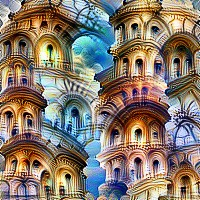

# Redes neurais e métodos post-hoc

## Tudo o que vimos vale para redes

Os métodos agnósticos das aulas anteriores só precisam consultar o modelo: dar uma entrada $\mathbf x$ e ler a saída $\hat f(\mathbf x)$. Uma rede neural é um modelo como outro qualquer.

**Explicações locais**

Ceteris paribus, ICE e LIME ([Aula 07](https://brunogrisci.github.io/aulas-interpretabilidade/aula07.html)); contrafactuais, anchors e recourse ([Aula 08](https://brunogrisci.github.io/aulas-interpretabilidade/aula08.html)); valores de Shapley e SHAP ([Aula 09](https://brunogrisci.github.io/aulas-interpretabilidade/aula09.html)).

**Explicações globais**

PDP, ALE, interações, PFI e LOFO ([Aula 10](https://brunogrisci.github.io/aulas-interpretabilidade/aula10.html)); surrogates, protótipos e criticisms ([Aula 11](https://brunogrisci.github.io/aulas-interpretabilidade/aula11.html)).

**O que eles não usam**

O que a rede aprendeu por dentro, nas camadas ocultas; e os gradientes, que ela calcula barato com o backpropagation ([Aula 13](https://brunogrisci.github.io/aulas-interpretabilidade/aula13.html)).

Bibliotecas para redes, como a [Captum](https://captum.ai/) (PyTorch), já trazem versões de alguns deles, como *Feature Ablation* e *Gradient SHAP*, ao lado de métodos que usam o gradiente, como *Integrated Gradients* e *DeepLIFT* — tema das Aulas 15 e 16.

Em imagens, porém, a unidade dessas explicações é o pixel, e a importância de um pixel isolado diz pouco. Nesta aula, a pergunta muda: *o que a rede aprendeu a detectar?*

Limite das explicações por pixel: [Molnar (2025), *Detecting Concepts*](https://christophm.github.io/interpretable-ml-book/detecting-concepts.html). Métodos post-hoc para redes: [Suwa, Silva e Grisci (2026)](https://linklings.s3.amazonaws.com/organizations/WCCI/wcci2026/submissions/stype114/khrGU-ijcnn_pap3544s2.pdf), §II-C; [Kokhlikyan et al. (2020)](https://arxiv.org/abs/2009.07896).

## Onde cada método interage com a rede

[figure not shown]

**Na entrada**

Uma camada extra aprende quanto cada atributo pesa para a rede: a Feature Selection Layer.

**Nas unidades ocultas**

Que entrada faz uma unidade disparar? Otimizar uma imagem, procurar no dataset, “sonhar”, mapear milhões de ativações.

**Entre unidades e conceitos**

A unidade 42 detecta “listras”? Um conceito humano influencia a classe “zebra”? Medir, em vez de olhar.

Organização da aula: capítulos *Learned Features* e *Detecting Concepts* de [Molnar (2025)](https://christophm.github.io/interpretable-ml-book/), com a Feature Selection Layer e o activation atlas como complementos.

# Feature Selection Layer

## Uma camada para pesar atributos

**Relembrando a [Aula 02](https://brunogrisci.github.io/aulas-interpretabilidade/aula02.html):** métodos embutidos selecionam atributos durante o próprio treino (LASSO, árvores). Uma rede neural não tem um mecanismo desses, a não ser que se coloque um.

[figure not shown]

$$\mathbf x'=a(\mathbf w)\odot\mathbf x,\qquad \hat y=f(\mathbf x'),\qquad
\underbrace{\ell\big(\hat y,y\big)}_{\text{errar a tarefa}}+\underbrace{\lambda\,r(\mathbf w)}_{\text{usar atributos}}$$

**$w_i$ e $a(\cdot)$**

Um peso treinável por atributo $x_i$, passado por uma ativação: sigmoide ou linear limitada a [0, 1] no original; ReLU no post-hoc. Sem viés.

**$\odot$**

Produto elemento a elemento: $x'_i=a(w_i)\,x_i$. Peso 0 apaga o atributo; peso alto o amplifica.

**$r(\mathbf w)$**

No original, $\lvert\sum_i w_i-1\rvert$: os pesos disputam uma soma fixa. No post-hoc, $\sum_i\lvert w_i\rvert$ (L1): todos são puxados para 0.

**$\lambda$**

Força da regularização. Só sobrevive o peso que “paga” o seu custo, reduzindo o erro mais do que custa.

[Figueroa Barraza, López Droguett e Martins (2021)](https://doi.org/10.3390/s21175888), §4.1 e eq. (4): início com pesos 1/n; [Suwa, Silva e Grisci (2026)](https://linklings.s3.amazonaws.com/organizations/WCCI/wcci2026/submissions/stype114/khrGU-ijcnn_pap3544s2.pdf), §III, eq. (2)–(3): início com pesos 1.

## FSL embutida × post-hoc

**1 · Inserir**

A FSL entra entre a entrada e uma rede **já treinada**, com todos os pesos em 1: no início, a rede vê os dados como sempre viu.

→

**2 · Propagar**

Os dados passam pela FSL e pela rede; a perda compara $\hat y$ com o rótulo e soma $\lambda\sum_i\lvert w_i\rvert$.

→

**3 · Congelar**

No backpropagation, só os $w_i$ recebem gradiente. A rede pré-treinada não muda.

→

**4 · Repetir e ler**

Após as épocas, $a(w_i)$ é a importância do atributo $i$ para **aquela** rede. Depois, a FSL pode ser removida.

**Embutida**

A rede aprende a tarefa e os pesos ao mesmo tempo: explica uma rede que já nasce com a FSL. Não serve para um modelo que já está em produção.

**Post-hoc**

Explica uma rede pronta sem mexer nela: treino curto, só $n$ parâmetros novos. Pergunta de que atributos **esta** rede depende.

[Suwa, Silva e Grisci (2026)](https://linklings.s3.amazonaws.com/organizations/WCCI/wcci2026/submissions/stype114/khrGU-ijcnn_pap3544s2.pdf), §III-B e fig. 1; [Figueroa Barraza et al. (2021)](https://doi.org/10.3390/s21175888), §4.1.

## Reprodução: XOR com ruído

O XOR da [Aula 02](https://brunogrisci.github.io/aulas-interpretabilidade/aula02.html), com 48 atributos de ruído: só $x_1$ e $x_2$ decidem a classe, e nenhum dos dois, sozinho, tem relação com ela. Nos pinguins, a rede prevê P(fêmea), e ninguém sabe de antemão quais atributos importam. Arraste as épocas.

Dados e protocolo do [código oficial](https://github.com/joaosuwa/FSL_post-hoc), reimplementados em NumPy: MLP 50–32–16–1 (XOR) e 100–128–64–32–1 (SynthA), com batch norm, ReLU e dropout; nos pinguins (333 completos; 4 medidas, espécie e ilha em one-hot), 10–32–16–1 com o protocolo do XOR; FSL com ReLU, início 1 e L1 (λ = 0,0025); AdamW; mostrada a 1ª de 11 dobras, com loss = BCE com pos_weight (sem o L1). Aqui, “embutida” é a variante do código do artigo post-hoc (ReLU e L1).

## Reprodução e artigo

|  | rede sem FSL | FSL embutida | FSL post-hoc |
| --- | --- | --- | --- |
| XOR: acurácia no teste | 1,000 | 1,000 | 1,000 |
| XOR: PIFS = PSFI (top 2) | — | 1,000 | 1,000 |
| SynthA: acurácia no teste | 0,911 | 0,954 | 0,938 |
| SynthA: PIFS = PSFI (top 30) | — | 1,000 | 0,861 |
| Pinguins: acurácia no teste | 0,897 | 0,900 | 0,905 |

**Reproduz o artigo**

**Em dados reais**

Em microarranjos (Liver-GSE22405), os pesos da post-hoc dão o t-SNE ponderado mais separado: silhueta 0,666, contra 0,17–0,20 dos outros métodos post-hoc.

**Limites**

Pior em problemas multiclasse (um peso por atributo não captura relações de cada classe); só para tabelas: num pixel, o significado muda de imagem para imagem.

Tabela: média de 11 dobras na reprodução. Artigo: [Suwa, Silva e Grisci (2026)](https://linklings.s3.amazonaws.com/organizations/WCCI/wcci2026/submissions/stype114/khrGU-ijcnn_pap3544s2.pdf), §V, tab. II–IV e §VI-A; t-SNE ponderado: [Grisci, Inostroza-Ponta e Dorn (2025)](https://doi.org/10.1016/j.neucom.2025.130561).

# Learned features

## O que uma CNN aprende

Uma CNN recebe os pixels crus e, camada após camada, constrói as suas próprias features — o trabalho que antes era feito à mão (cores, frequências, detectores de bordas) para alimentar, por exemplo, uma SVM.

[figure not shown]

[figure not shown]

**Bordas**  
conv2d0

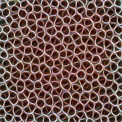

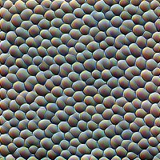

**Texturas**  
mixed3a

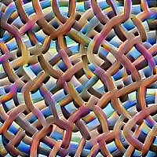

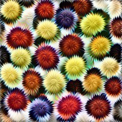

**Padrões**  
mixed4a

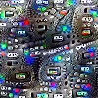

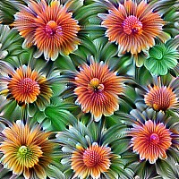

**Partes**  
mixed4b e 4c

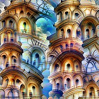

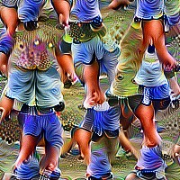

**Objetos**  
mixed4d e 4e

As primeiras camadas aprendem bordas e texturas simples; as do meio, padrões mais complexos; as últimas convolucionais, partes e objetos. As camadas densas ligam essas features às classes.

Feature visualizations do GoogLeNet (Inception V1) treinado no ImageNet: [Olah, Mordvintsev e Schubert (2017)](https://distill.pub/2017/feature-visualization/), figura de abertura, CC BY 4.0; [todos os canais no apêndice](https://distill.pub/2017/feature-visualization/appendix/). Texto: [Molnar (2025), *Learned Features*](https://christophm.github.io/interpretable-ml-book/cnn-features.html). Relembrando: [Aula 02](https://brunogrisci.github.io/aulas-interpretabilidade/aula02.html) e [Aula 13](https://brunogrisci.github.io/aulas-interpretabilidade/aula13.html).

## A CNN desta aula

Para reproduzir os métodos, uma CNN pequena, treinada por nós. Os resultados com o GoogLeNet, a AlexNet e o InceptionV3 vêm dos artigos originais.

[figure not shown]

**Unidades**

Cada **canal** da conv1 e da conv2 é um mapa de ativações; cada posição $(u,v)$ dele é um **neurônio**. A densa tem 64 neurônios; a saída, 10 **logits**.

**Olhar os pesos não basta**

Já na conv1, cada filtro é uma janela de 5 × 5 pesos difícil de ler. Na conv2, cada filtro tem 16 × 5 × 5 = 400 pesos, que combinam os mapas da conv1.

**A pergunta da próxima seção**

Em vez dos pesos, olhar o comportamento: que imagem faz cada unidade disparar mais?

Entrada: intensidade dos pixels em [0, 1], sem padronização, para que as imagens otimizadas vivam no mesmo intervalo dos dígitos. Pesos de He, semente 2026, NumPy com a retropropagação escrita à mão.

# Feature visualization

## Qual unidade visualizar?

Feature visualization: encontrar a entrada que mais ativa uma unidade da rede. A primeira escolha é qual unidade.

[figure not shown]

**$h_{n,u,v,z}(\mathbf x)$**

Ativação, para a imagem $\mathbf x$, do neurônio da camada $n$, na posição $(u,v)$ do canal $z$.

**canal**

O mapa inteiro de um filtro: o mesmo detector em todas as posições. É o objetivo mais usado.

**camada**

Todos os canais juntos: a imagem que a camada acha “interessante”. É o objetivo do DeepDream.

**logit × probabilidade**

Para aumentar a probabilidade de uma classe, basta derrubar as outras; os logits dão imagens melhores.

Unidades: [Molnar (2025), *Learned Features*](https://christophm.github.io/interpretable-ml-book/cnn-features.html), fig. *units*. Imagens otimizadas no GoogLeNet: [Olah, Mordvintsev e Schubert (2017)](https://distill.pub/2017/feature-visualization/#optimization-objectives), *Optimization Objectives*, CC BY 4.0. Uma rede tem milhões de neurônios; o Inception V1 tem mais de 5.000 canais em 9 camadas.

## Visualizar é otimizar a entrada

$$\mathbf x^*=\arg\max_{\mathbf x}\;h_{n,u,v,z}(\mathbf x)\qquad\text{ou, para o canal inteiro,}\qquad \mathbf x^*=\arg\max_{\mathbf x}\;\sum_{u,v}h_{n,u,v,z}(\mathbf x)$$

**$\mathbf x$ e $\mathbf x^*$**

A imagem de entrada, pixel a pixel: aqui, é ela que se otimiza. $\mathbf x^*$ é a imagem que dá a maior ativação.

**$h$**

Ativação: o número que uma unidade da rede produz para a imagem $\mathbf x$, com os pesos fixos.

**$n$ e $z$**

A camada da rede e, dentro dela, o canal: o mapa de saída de um filtro.

**$u$ e $v$**

Linha e coluna do neurônio no mapa do canal. Somar em $u,v$ dá o mesmo peso a todas as posições.

**Treinar ([Aula 13](https://brunogrisci.github.io/aulas-interpretabilidade/aula13.html))**

A imagem fica fixa; os pesos $\mathbf w$ mudam, **descendo** a perda $L$ em passos de tamanho $\eta$: $\mathbf w\leftarrow\mathbf w-\eta\,\nabla_{\mathbf w}L$.

**Visualizar**

Os pesos ficam fixos; os pixels mudam, **subindo** a ativação: $\mathbf x\leftarrow\mathbf x+\eta\,\nabla_{\mathbf x}h(\mathbf x)$. O gradiente $\nabla_{\mathbf x}h$ vem do mesmo backpropagation, levado até a entrada.

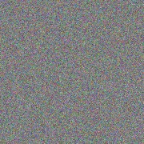

passo **0**: ruído

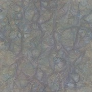

passo **4**

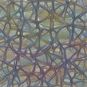

passo **48**

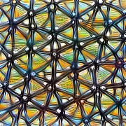

passo **2048**

Equações: [Molnar (2025)](https://christophm.github.io/interpretable-ml-book/cnn-features.html#feature-visualization-through-optimization). Imagens: otimização a partir de ruído para a unidade 11 da camada mixed4a do GoogLeNet, [Olah, Mordvintsev e Schubert (2017)](https://distill.pub/2017/feature-visualization/#optimization), CC BY 4.0.

## Reprodução: nossa CNN

Subida do gradiente a partir de ruído, 512 passos. Escolha a unidade e a regularização — e compare “sem restrição” com as demais.

CNN da aula; objetivos: logit (antes do softmax) ou pré-ativação do neurônio central de um canal — com a média espacial do canal, vários ficam pretos: no MNIST a feature é local e não se repete pela imagem. Adam na entrada 28 × 28 (taxa 0,02 nos pixels; 0,3 no espaço de frequências), semente 2026. Penalização de frequência: L2 e variação total com peso 0,1 sobre o gradiente normalizado, blur gaussiano σ = 0,5 a cada 4 passos; transformações: deslocamento aleatório de até 2 pixels; espaço de frequências: imagem = sigmoide(DCT inversa dos parâmetros × 1/frequência), versão com DCT da parametrização de [Olah et al. (2017)](https://distill.pub/2017/feature-visualization/#preconditioning).

## O inimigo: alta frequência

Otimizar os pixels sem restrição nenhuma quase nunca funciona: surge uma “ilusão de ótica” da rede, cheia de padrões de alta frequência que a ativam fortemente.

**Alta frequência:** a frequência (espacial) diz quão depressa a intensidade da imagem oscila de um ponto a outro. É alta num tabuleiro ou num ruído granulado, que alternam claro e escuro a cada pixel ou dois; é baixa num céu liso.

[figure not shown]

Magnitude do gradiente voltando por cada camada, da entrada (esquerda) à mixed5a (direita). Cada convolução com passo e cada max-pooling acrescenta um padrão de tabuleiro.

**Parente dos exemplos adversariais**

Mesma maximização de uma unidade. Na feature visualization, parte-se de ruído; num exemplo adversarial, de uma imagem real, rumo à classe errada ([Aula 17](https://brunogrisci.github.io/aulas-interpretabilidade/aula17.html)).

[Olah, Mordvintsev e Schubert (2017)](https://distill.pub/2017/feature-visualization/#enemy-of-feature-vis), *The Enemy of Feature Visualization*: sprites originais da figura interativa, CC BY 4.0; tabuleiros: [Odena, Dumoulin e Olah (2016)](https://distill.pub/2016/deconv-checkerboard/). Ligação com exemplos adversariais: [Molnar (2025)](https://christophm.github.io/interpretable-ml-book/cnn-features.html#connection-to-adversarial-examples).

## Regularização

Regularizar é restringir a busca por $\mathbf x$ para que ela chegue a imagens naturais. As formas dos próximos slides cabem em $\mathbf x^*=\arg\max_{\mathbf x}\,{\color{#7A5195}{\mathbb E_{T}[h(T(\mathbf x))]}}\,{\color{#174A6E}{-}}\,{\color{#0072B2}{\lambda R(\mathbf x)}}$: robustez a transformações menos penalização.

| termo | definição | exemplo |
| --- | --- | --- |
| Regularização | Toda restrição que puxa $\mathbf x$ para imagens naturais, em vez de deixar a subida explorar qualquer padrão que ative a unidade. | Recortar os pixels em [0, 1] já é uma regularização, fraca. |
| Fraca × forte | Fraca: mostra o que a rede busca, mas em imagens que ela não vê em uso. Forte: imagens realistas, com risco de correlações enganosas. | Os extremos: exemplos adversariais e exemplos do dataset. |
| Correlações enganosas | Coisas que aparecem juntas nas imagens reais: pela imagem, não se sabe a qual delas a unidade responde. | Cachorros quase sempre com bola de tênis: é a bola ou o cachorro? |
| Penalização | Termo $\lambda R(\mathbf x)$ subtraído do objetivo: $R$ mede o que não se quer na imagem, e $\lambda\ge 0$ dá o seu peso. | Com $\lambda$ grande, vale mais ser lisa do que ativar a unidade. |
| Variação total | $R(\mathbf x)=\sum\lvert x_i-x_j\rvert$, somando sobre os pares $i,j$ de pixels vizinhos. | Zero se a imagem é lisa; máxima num tabuleiro. |
| L1 e L2 | Penalizam o tamanho dos pixels: $\sum_i\lvert x_i-c\rvert$ ou $\sum_i(x_i-c)^2$, com $c$ fixo. | Com $c=0$, pixels inúteis voltam ao preto. |
| Blur | Trocar cada pixel por uma média (gaussiana) dos vizinhos, o que apaga as frequências altas. O filtro bilateral faz o mesmo sem cruzar bordas. | Um blur a cada 4 passos, na CNN da aula. |
| Robustez a transformações | Otimizar a média $\mathbb E_T$ do objetivo sobre transformações aleatórias $T$ da imagem, sorteando uma $T$ a cada passo. | Um padrão que só ativa a unidade numa posição exata desaparece. |
| Jitter | A transformação mais simples: deslocar a imagem alguns pixels, ao acaso. | Até 2 px na CNN da aula; 16 px na Distill. |
| Rotação e escala | Girar a imagem alguns graus ou ampliá-la e reduzi-la um pouco, ao acaso. | ±5° e 0,95–1,05× na receita da Distill. |
| Prior | O que se supõe sobre as imagens antes de olhar a rede: uma distribuição $p(\mathbf x)$ das imagens plausíveis. Penalizar com $R(\mathbf x)=-\log p(\mathbf x)$ é usar esse prior. | “Imagens naturais são quase lisas” está por trás da variação total. |
| Prior aprendido | Um $p(\mathbf x)$ aprendido de imagens reais por um modelo gerativo: GAN, VAE ou denoising autoencoder. | Otimizar o código de entrada de um gerador, e não os pixels. |

[Olah, Mordvintsev e Schubert (2017)](https://distill.pub/2017/feature-visualization/#regularization), *The Spectrum of Regularization*, *Three Families of Regularization* e, para a receita final, *Preconditioning and Parameterization*; [Molnar (2025)](https://christophm.github.io/interpretable-ml-book/cnn-features.html#feature-visualization-through-optimization). Variação total: [Mahendran e Vedaldi (2015)](https://arxiv.org/abs/1412.0035), na sua forma mais simples.

## O espectro da regularização

Os principais trabalhos de feature visualization se distinguem pela regularização. Entre os extremos — nenhuma e só imagens reais — há três famílias, e muitos trabalhos combinam duas.

[figure not shown]

Um prior aprendido dá as imagens mais realistas — mas fica menos claro o que veio da rede visualizada e o que veio do prior.

[Olah, Mordvintsev e Schubert (2017)](https://distill.pub/2017/feature-visualization/#regularization), *The Spectrum of Regularization*, com as imagens de cada trabalho: [Erhan et al. (2009)](https://api.semanticscholar.org/CorpusID:15127402), [Szegedy et al. (2013)](https://arxiv.org/abs/1312.6199), [Mahendran e Vedaldi (2015)](https://arxiv.org/abs/1412.0035), [Nguyen et al. (2015)](https://arxiv.org/abs/1412.1897), [Mordvintsev et al. (2015)](https://research.googleblog.com/2015/06/inceptionism-going-deeper-into-neural.html), [Øygard (2015)](https://www.auduno.com/2015/07/29/visualizing-googlenet-classes/), [Tyka (2016)](https://mtyka.github.io/deepdream/2016/02/05/bilateral-class-vis.html), [Mordvintsev (2016)](https://github.com/tensorflow/tensorflow/blob/master/tensorflow/examples/tutorials/deepdream/deepdream.ipynb), [Nguyen et al. (2016a)](https://arxiv.org/abs/1605.09304), [Nguyen et al. (2016b)](https://arxiv.org/abs/1612.00005).

## Três famílias de regularização

**Penalização de frequência**

A variação total pune a diferença entre pixels vizinhos; o blur borra a imagem a cada passo. Os dois também apagam bordas legítimas; um filtro bilateral, que preserva as bordas, no lugar do blur, melhora um pouco. No interativo, o L1 pune ainda a distância de cada pixel a um valor fixo. Cada controle dá o peso do seu termo.

**Robustez a transformações**

Antes de cada passo, o jitter desloca, a rotação gira e a escala amplia a imagem ao acaso, até o máximo do controle: só sobrevive o que ativa a unidade de qualquer jeito. Pouco já basta, sobretudo junto com uma penalização de frequência.

**Prior aprendido**

Otimiza no espaço latente de uma GAN ou VAE, ou junto com um prior aprendido (um denoising autoencoder). Outra via: aproximar cada pedaço da imagem do pedaço mais parecido do treino. Imagens realistas, mas o prior também “desenha”.

[Olah, Mordvintsev e Schubert (2017)](https://distill.pub/2017/feature-visualization/#regularization-families), *Three Families of Regularization*: sprites originais, CC BY 4.0 (3 dos 6 neurônios da figura). Filtro bilateral: [Tyka (2016)](https://mtyka.github.io/deepdream/2016/02/05/bilateral-class-vis.html); pedaços do treino: [Wei et al. (2015)](https://arxiv.org/abs/1507.02379). Prior aprendido: imagens da figura 1 de [Nguyen et al. (2016a)](https://arxiv.org/abs/1605.09304) e de [Nguyen et al. (2016b)](https://arxiv.org/abs/1612.00005). Valores dos controles como no artigo, onde as penalidades entram com sinal negativo no objetivo.

## Precondicionamento

Mesmo objetivo, outra parametrização: fazer a subida num espaço de Fourier descorrelacionado, onde as frequências altas andam devagar. A direção de maior subida muda muito com a noção de distância — L∞, a dos exemplos adversariais; L2, o gradiente comum:

**Direção de maior subida:** \(\mathbf d^*=\arg\max_{\lVert\mathbf d\rVert\le\epsilon}\nabla_{\mathbf x}h\cdot\mathbf d\), o passo de tamanho \(\epsilon\) que mais aumenta \(h\). Depende de como se mede \(\lVert\mathbf d\rVert\):

**L∞** · exemplos adversariais. \(\lVert\mathbf d\rVert_\infty=\max_i\lvert d_i\rvert\), a maior mudança de um pixel. Melhor passo: \(\mathbf d=\epsilon\,\mathrm{sinal}(\nabla_{\mathbf x}h)\), todo pixel \(\pm\epsilon\) (o FGSM).

**L2** · gradiente comum. \(\lVert\mathbf d\rVert_2^2=\sum_i d_i^2\), a distância euclidiana. Melhor passo: \(\mathbf d\propto\nabla_{\mathbf x}h\), a subida usada até aqui.

**descorrelacionado** · receita da Distill. L2 nos coeficientes de Fourier, escalados para que toda frequência tenha a mesma energia (e com cores descorrelacionadas). Melhor passo: o gradiente com as frequências altas amortecidas, como no nosso "espaço de frequências".

[Olah, Mordvintsev e Schubert (2017)](https://distill.pub/2017/feature-visualization/#preconditioning), *Preconditioning and Parameterization*, CC BY 4.0 (sprites originais da figura das três direções). FGSM: [Goodfellow, Shlens e Szegedy (2015)](https://arxiv.org/abs/1412.6572). Receita final do artigo: 2.560 passos de Adam (taxa 0,05) no espaço de Fourier com cores descorrelacionadas; a cada passo, borda de 16 px, jitter de até 16 e 8 px, escala entre 0,95 e 1,05 e rotação entre −5° e 5°.

## Um neurônio, várias facetas

A otimização devolve um exemplo extremo — uma faceta só. Um termo de diversidade força várias imagens a serem diferentes entre si.

[interactive chart not shown]

**otimização simples**

[interactive chart not shown]

**com termo de diversidade**: 4 imagens otimizadas juntas

[interactive chart not shown]

**exemplos do dataset**

Diversidade: otimizar juntas 4 imagens, somando ao objetivo o **negativo da similaridade** entre elas (cosseno entre suas matrizes de Gram, como na transferência de estilo). A pressão por diferença às vezes inventa detalhes, como olhos.

Neurônios não são necessariamente as unidades semânticas certas: um mesmo neurônio pode misturar gatos, raposas e carros — a polissemantia da [Aula 13](https://brunogrisci.github.io/aulas-interpretabilidade/aula13.html).

[Olah, Mordvintsev e Schubert (2017)](https://distill.pub/2017/feature-visualization/#diversity), *Diversity*, CC BY 4.0. Outras abordagens: agrupar ativações e otimizar os centroides ([Wei et al., 2015](https://arxiv.org/abs/1507.02379)); partir de exemplos diversos ([Nguyen et al., 2016](https://arxiv.org/abs/1602.03616)).

## Neurônios interagem

No espaço de ativações, cada neurônio é um eixo; qualquer combinação deles é uma direção — e também pode ser visualizada.

[figure not shown]

**O que é uma direção**

Para uma imagem $\mathbf x$, os neurônios de uma camada dão um vetor de ativações $\mathbf h(\mathbf x)$, um eixo por neurônio. Uma direção é um vetor de pesos $\mathbf v$, um por neurônio, e visualizá-la é maximizar $\mathbf v\cdot\mathbf h(\mathbf x)=\sum_i v_i\,h_i(\mathbf x)$. No desenho, com dois neurônios: um neurônio sozinho é (1, 0) ou (0, 1); a soma, (1, 1); a interpolação, (1 − t, t), com t de 0 a 1; numa direção aleatória, os pesos são sorteados e podem ser negativos.

[Olah, Mordvintsev e Schubert (2017)](https://distill.pub/2017/feature-visualization/#interaction), *Interaction between Neurons*: sprites originais, CC BY 4.0. Direções com pesos negativos: [Molnar (2025)](https://christophm.github.io/interpretable-ml-book/cnn-features.html#feature-visualization-through-optimization). Direções aleatórias parecem tão interpretáveis quanto neurônios para [Szegedy et al. (2013)](https://arxiv.org/abs/1312.6199), e menos para [Bau et al. (2017)](https://arxiv.org/abs/1704.05796) — tema da seção Network Dissection.

# Maximum activation examples

## Exemplos do dataset × otimização

A alternativa mais simples: procurar, entre as imagens de treino, as que mais ativam a unidade.

[figure not shown]

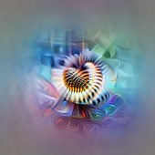

**Beisebol — ou listras?**  
mixed4a, unidade 6

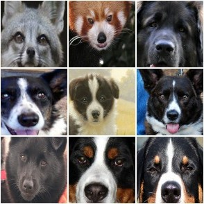

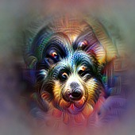

**Caras de animais — ou focinhos?**  
mixed4a, unidade 240

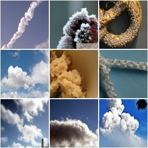

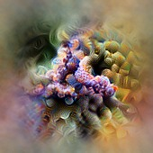

**Nuvens — ou fofura?**  
mixed4a, unidade 453

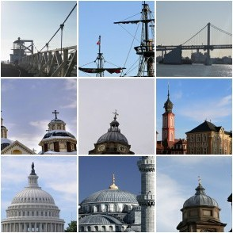

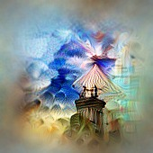

**Prédios — ou céu?**  
mixed4a, unidade 492

**Exemplos do dataset**

Mostram o que ativa a unidade na prática, com imagens reais e variadas. Mas carregam correlações: se as fotos mostram um cachorro com uma bola de tênis, a unidade olha para o cachorro, para a bola ou para os dois?

**Otimização**

Isola a causa da correlação (acima, as listras, não a bola) e é flexível: combinar unidades, acompanhar o treino. Mas produz imagens que não existem.

[Olah, Mordvintsev e Schubert (2017)](https://distill.pub/2017/feature-visualization/#why-optimization), *Why visualize by optimization?*, CC BY 4.0; exemplo do cachorro: [Molnar (2025)](https://christophm.github.io/interpretable-ml-book/cnn-features.html#feature-visualization-through-optimization).

## O espectro de ativações

Com o dataset, dá para ver a unidade inteira, do mais negativo ao mais positivo — não só o extremo. Escolha um neurônio.

A direção negativa não é “ausência”: é outra feature. No neurônio 484 da mixed4d (antes da ReLU), o lado positivo mostra rodas; o negativo, algo com olhos. Os exemplos do espectro ajudam a checar as hipóteses sugeridas pela otimização.

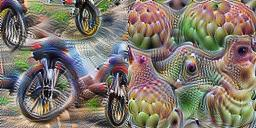

[Olah, Mordvintsev e Schubert (2017)](https://distill.pub/2017/feature-visualization/#diversity), fig. *optimization and examples*, sprites originais, CC BY 4.0. Neurônio 484: [Molnar (2025)](https://christophm.github.io/interpretable-ml-book/cnn-features.html#feature-visualization-through-optimization), com imagens de Olah et al.

## Reprodução: os canais da nossa CNN

[interactive chart not shown]

**negativo** otimizado

[interactive chart not shown]

9 ativações **mínimas**

[interactive chart not shown]

9 ativações **máximas**

[interactive chart not shown]

**positivo** otimizado

Em 30 dos 32 canais da conv2, pelo menos dois dígitos aparecem cinco vezes ou mais entre as 50 imagens mais fortes: o canal responde a um traço, não a uma classe. Use “sortear canal”: uma galeria escolhida a dedo esconderia os canais confusos.

Imagens de teste do MNIST (10 mil) ordenadas pela maior (ou menor) pré-ativação do canal em qualquer posição: o neurônio do canal que mais dispara. Visualizações do neurônio central, com robustez a transformações: positivo e com o sinal trocado (negativo); tracejado: campo receptivo. Mapa em laranja: ativação do canal (após a ReLU), ampliada de 14 × 14 para 28 × 28.

## Além das imagens

**Dados tabulares**

Nada impede de otimizar a entrada de uma rede densa, como a do XOR. Mas a “feature” de um neurônio vira uma combinação de dezenas de atributos (créditos anteriores, contratos de celular, endereço…), e a imagem vira uma tabela.

**Texto**

Karpathy et al. (2015) treinaram uma rede recorrente para prever o próximo caractere e procuraram neurônios pelas ativações no próprio texto: um liga ao abrir “(” e desliga no “)”; outros disparam no fim da linha ou dentro de URLs.

No caso do texto, as features foram encontradas como **exemplos do dataset**, não por otimização: um texto otimizado seria uma sequência de caracteres sem sentido.

[Molnar (2025)](https://christophm.github.io/interpretable-ml-book/cnn-features.html#text-and-tabular-data), *Text and tabular data*; [Karpathy, Johnson e Fei-Fei (2015)](https://arxiv.org/abs/1506.02078).

# DeepDream

## Sonhar com uma camada

DeepDream parte de uma foto, não de ruído, e maximiza uma camada inteira: o que a camada já vê um pouco fica mais forte a cada passo. É uma pareidolia algorítmica.

$$\mathbf x\leftarrow\mathbf x+\eta\,\frac{\mathbf g}{\operatorname{média}\lvert\mathbf g\rvert},\qquad \mathbf g=\nabla_{\mathbf x}\,\tfrac12\big\lVert h_l(\mathbf x)\big\rVert^2$$

**$\mathbf x$**

A imagem, pixel a pixel: começa na foto e muda a cada passo; os pesos da rede ficam fixos.

**$\mathbf g$**

O gradiente do objetivo em relação aos pixels: para que lado mexer em cada um para a camada ativar mais.

**$\eta$**

O tamanho do passo (taxa de aprendizado): quanto a imagem muda por iteração.

**$h_l(\mathbf x)$**

Todas as ativações da camada $l$ para a imagem $\mathbf x$.

**$\tfrac12\lVert h_l\rVert^2$**

A soma dos quadrados: cada neurônio “puxa” na proporção do quanto já está ativo, daí a realimentação.

**$\operatorname{média}\lvert\mathbf g\rvert$**

Normaliza o passo; jitter e várias escalas (oitavas) evitam os padrões de alta frequência.

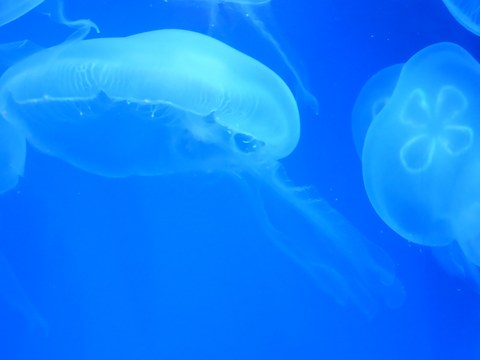

original

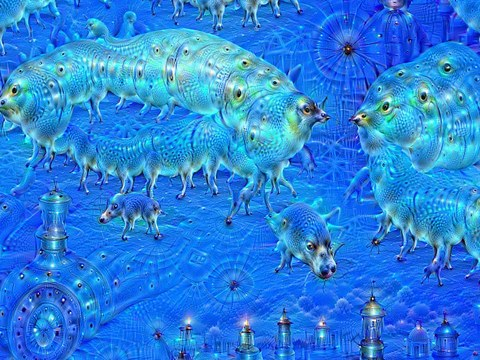

10 iterações

[figure not shown]

50 iterações

[figure not shown]

Mona Lisa (VGG16)

[Mordvintsev, Olah e Tyka (2015), *Inceptionism*](https://research.googleblog.com/2015/06/inceptionism-going-deeper-into-neural.html); [Wikipedia, *DeepDream*](https://en.wikipedia.org/wiki/DeepDream). Imagens do Wikimedia Commons em domínio público (CC0): água-viva, [MartinThoma](https://commons.wikimedia.org/wiki/File:Aurelia-aurita-3-0049.jpg); Mona Lisa, [Pjfinlay](https://commons.wikimedia.org/wiki/File:%22Mona_Lisa%22_with_DeepDream_effect_using_VGG16_network_trained_on_ImageNet.jpg). Pareidolia: [Aula 03](https://brunogrisci.github.io/aulas-interpretabilidade/aula03.html).

## Reprodução: os sonhos da nossa CNN

A mesma regra na CNN do MNIST, a partir de dígitos de teste. Troque o objetivo: uma camada inteira, ou o logit de uma classe — deixar a imagem “mais parecida com um 8”.

Com o logit do 8 como objetivo, os 10 dígitos terminam classificados como “8” com probabilidade de pelo menos 99,9%: a rede “vê” o que a otimização desenhou para ela.

40 iterações com passo η = 0,02 sobre o gradiente normalizado, deslocamento aleatório de até 2 pixels e recorte em [0, 1]; sem oitavas (28 × 28 pixels). Clique numa iteração para ver as probabilidades.

## *Deep Dream (Google)* (Computerphile)

[video not shown]

[Abrir o vídeo no YouTube](https://www.youtube.com/watch?v=BsSmBPmPeYQ)

# Activation atlas

## De neurônios a ativações

A rede quase nunca usa um neurônio sozinho. Olhar neurônio por neurônio é como estudar só as 26 letras: elas formam todas as palavras do português, mas são as palavras que de fato aparecem nos textos que mostram o que se diz. O activation atlas mostra as “palavras” da rede: as *combinações* de neurônios (vetores de ativação) que aparecem com imagens reais.

**1 · Amostrar**

1 milhão de imagens; de cada uma, o vetor de um pedaço sorteado (abaixo).

→

**2 · Projetar**

UMAP leva os vetores a 2D, com ativações parecidas perto umas das outras.

→

**3 · Agregar**

Uma grade sobre o mapa; em cada célula, a média $\mathbf v$ das ativações que caíram ali.

→

**4 · Inverter**

Feature visualization da média, com objetivo $(\mathbf h\cdot\mathbf v)\cdot\cos(\mathbf h,\mathbf v)$; rótulo pela classe que a célula mais apoia.

[figure not shown]

A atribuição de uma ativação $\mathbf h$ a uma classe é $\mathbf h\cdot\nabla_{\mathbf h}\,\text{logit}_c$: quanto o logit mudaria, em primeira ordem, se a ativação fosse zerada.

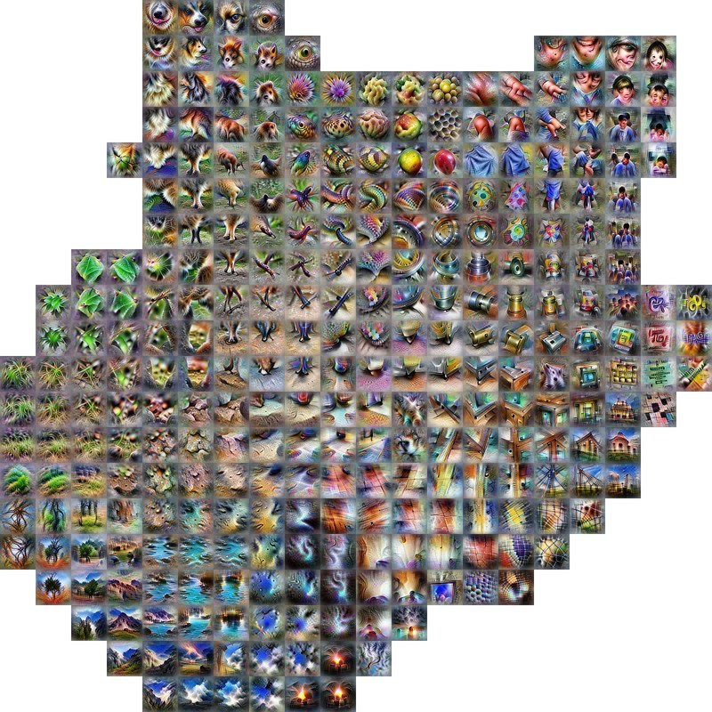

Atlas da mixed4c do InceptionV1 (1 milhão de ativações, grade 20 × 20).

[Carter, Armstrong, Schubert, Johnson e Olah (2019)](https://distill.pub/2019/activation-atlas/), *Aggregating Multiple Images* e *Technical Notes*, CC BY 4.0; foto e visualização do pedaço: a grade de ativações do artigo (14 × 14 posições, na mixed4d); UMAP: [McInnes, Healy e Melville (2018)](https://arxiv.org/abs/1802.03426). Atribuição como em *Building Blocks*: [Olah et al. (2018)](https://distill.pub/2018/building-blocks/).

## Reprodução: o atlas da nossa conv2

[interactive chart not shown]

ícone: imagem otimizada para a **média** das ativações da célula

6 recortes reais da célula (campo receptivo de 14 × 14 pixels)

20.000 imagens de treino; de cada uma, o vetor de 32 ativações da conv2 numa posição sorteada com probabilidade proporcional à sua norma, longe das bordas. t-SNE (perplexidade 50, distância do cosseno) no lugar do UMAP; grade 14 × 14, células com pelo menos 12 ativações (128 células). Inversão do neurônio central com penalização de frequência, sem o branqueamento do notebook oficial (aqui ele piorou os ícones); contraste de cada ícone esticado.